# RNA-seq analysis in R

Daniel Soto

2024-01-27

## loading libraries

```r
library(DESeq2)
library(GEOquery)
library(NOISeq)
library(apeglm)
library(DESeq2)
```

## downloading data

```r
setwd("C:/Users/danie/OneDrive/Documents/bioinformatic_pipelines/class_1/hw_1")
getwd()
```

```
## [1] "C:/Users/danie/OneDrive/Documents/bioinformatic_pipelines/class_1/hw_1"
```

```r
urld <- "https://www.ncbi.nlm.nih.gov/geo/download/?acc=GSE198533&format=file&file=GSE198533%5FRaw%5Fgene%5Fcounts%5Fmatrix%2Ecsv%2Egz"
path <- paste(urld, "acc=GSE198533", "GSE198533_Raw_gene_counts_matrix.csv.gz", sep="&");
GSE198533_count <- as.matrix(data.table::fread(path, header=T, colClasses="integer"), rownames=1)
```

```
## Warning in data.table::fread(path, header = T, colClasses = "integer"): Attempt
## to override column 36 <<BDV3_fpkm>> of inherent type 'float64' down to 'int32'
## ignored. Only overrides to a higher type are currently supported. If this was
## intended, please coerce to the lower type afterwards.
```

```
## Warning in data.table::fread(path, header = T, colClasses = "integer"): Attempt
## to override column 37 <<BDV4_fpkm>> of inherent type 'float64' down to 'int32'
## ignored. Only overrides to a higher type are currently supported. If this was
## intended, please coerce to the lower type afterwards.
```

```
## Warning in data.table::fread(path, header = T, colClasses = "integer"): Attempt
## to override column 38 <<BDV5_fpkm>> of inherent type 'float64' down to 'int32'
## ignored. Only overrides to a higher type are currently supported. If this was
## intended, please coerce to the lower type afterwards.
```

```
## Warning in data.table::fread(path, header = T, colClasses = "integer"): Attempt
## to override column 39 <<BDV6_fpkm>> of inherent type 'float64' down to 'int32'
## ignored. Only overrides to a higher type are currently supported. If this was
## intended, please coerce to the lower type afterwards.
```

The warning obtained is produced because the first column is string type and cannot be converted to a integer type. Additionally columns from 20 to 38 are related to Fragments Per Kilobase Million (FPKM) data, which is a normalization that will not be used during this analysis. The data in those columns is a float64 data type and could not be converted to int32 data type. In the next chunk I removed columns from 20 to 38. In this way, the matrix will be composed only by the gene id and the read count.

```r
GSE198533_count <- GSE198533_count[, -c(20:38)]
```

## Getting the metadata and assigning factors

```r
gds <- getGEO("GSE198533")
```

```
## Found 1 file(s)
```

```
## GSE198533_series_matrix.txt.gz
```

```r
Meta_GSE198533 <- pData(gds$GSE198533_series_matrix.txt.gz@phenoData)
Meta_GSE198533 <- Meta_GSE198533[,c("title","source_name_ch1","characteristics_ch1","characteristics_ch1.1","condition:ch1")]
```

## Getting the annoatated data from Biomart

```r
write.table(rownames(GSE198533_count),"gene_names.txt",
            col.names = FALSE,row.names = FALSE,quote=F)

annotgene <- read.csv("mart_export.txt",sep="\t",header = T)
```

# Filtering the data and getting annotated genes

```r
# How many genes do I get annotated?
sum(rownames(GSE198533_count) %in% annotgene$Gene.stable.ID)
```

```
## [1] 58228
```

```r
# Filter the information so only contains annotated gene in ch 1-22, x and y
annotgene <- annotgene[annotgene$Chromosome.scaffold.name %in% c(as.character(1:22) ,"X","Y"),]
sum(rownames(GSE198533_count) %in% annotgene$Gene.stable.ID)
```

```
## [1] 58137
```

```r
## Checking for duplicates and assigning new row names to the annotated data
any(duplicated(annotgene$Gene.stable.ID))
```

```
## [1] FALSE
```

```r
rownames(annotgene) <- annotgene$Gene.stable.ID

#assign gene id as row names for the filtered df
sum(as.character(rownames(annotgene)) %in% rownames(GSE198533_count))
```

```
## [1] 58137
```

```r
##  Work with the annotated genes!

GSE198533_count_filt <- GSE198533_count[rownames(GSE198533_count) %in% rownames(annotgene),]
annotgene_ord <- annotgene[rownames(GSE198533_count_filt ),]
```

Last validation that shows how the row names of annotated data match with those of the filtered counts data

```r
all(rownames(annotgene_ord)==rownames(GSE198533_count_filt))
```

```
## [1] TRUE
```

# NOISeq QC

Creating the NOISeq data from the annotated data and filtered count data

```r
Factors_GSE198533 <- data.frame(Meta_GSE198533[,c("condition:ch1")])
colnames(Factors_GSE198533)[1]<- "Group"

####
##assigning values to length, gc content and chr # to use NOISEQ
####

lengthuse <- abs(annotgene_ord$Gene.end..bp.-annotgene_ord$Gene.start..bp.)
names(lengthuse) <- rownames(annotgene_ord)
gc <- annotgene_ord$Gene...GC.content
names(gc) <- rownames(annotgene_ord)
biotype <- annotgene_ord$Gene.type
names(biotype) <- rownames(annotgene_ord)
chromosome <- annotgene_ord[,c("Chromosome.scaffold.name","Gene.start..bp.","Gene.end..bp.")]

#creating NOISeq data
data_NOISEQ <- readData(data = GSE198533_count_filt,
                        length= lengthuse,
                        gc= gc,
                        biotype= biotype,
                        chromosome = chromosome,
                        factors = Factors_GSE198533)
```

```r
myexplodata <- dat(data_NOISEQ, type = "biodetection")
```

```
## Biotypes detection is to be computed for:
##  [1] "HC1_count"  "HC2_count"  "HC3_count"  "HC4_count"  "HC5_count"
##  [6] "HC6_count"  "HC7_count"  "HC8_count"  "HC9_count"  "HC10_count"
## [11] "BDU1_count" "BDU2_count" "BDU3_count" "BDV1_count" "BDV2_count"
## [16] "BDV3_count" "BDV4_count" "BDV5_count" "BDV6_count"
```

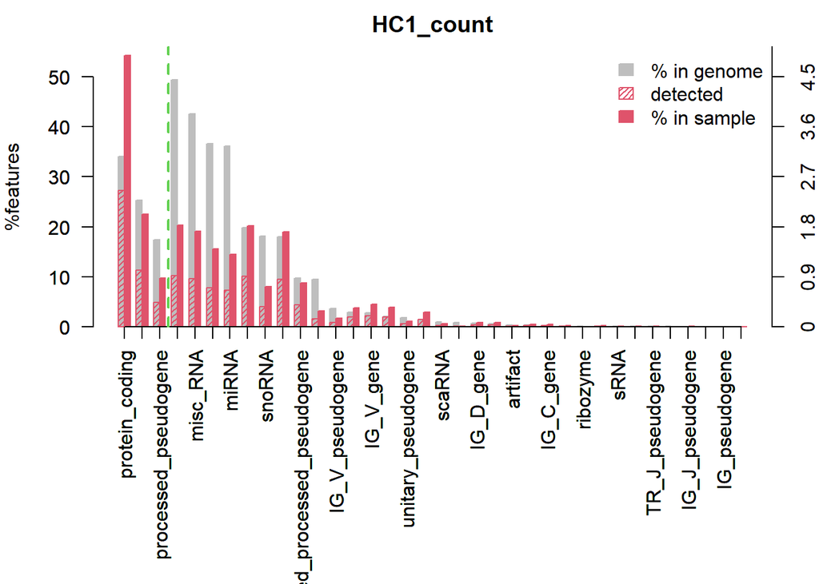

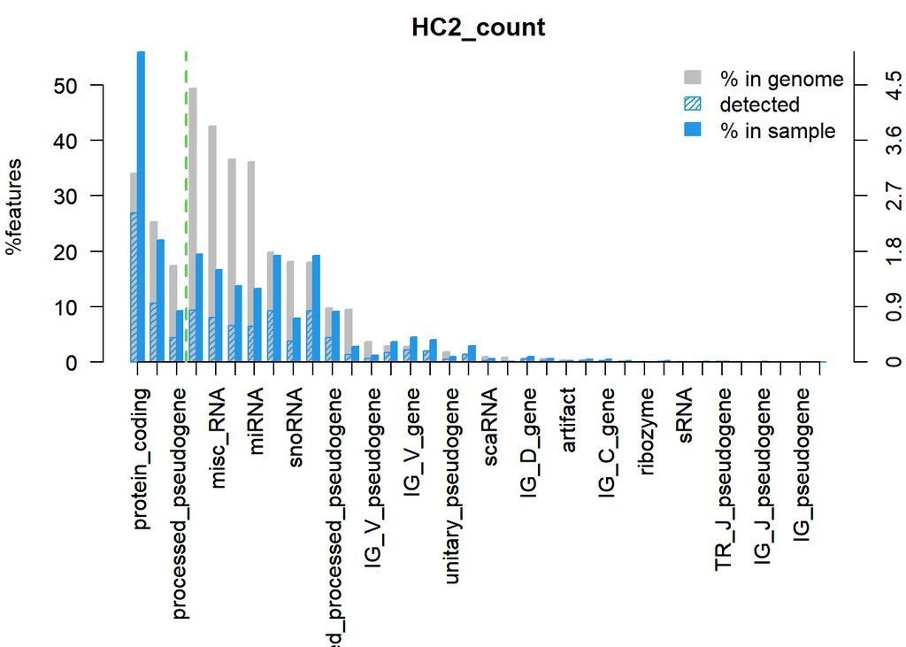

```r
explo.plot(myexplodata, plottype = "persample")
```

**In this plot we can see that as expected, the majority of the reads are from protein-coding mRNA**

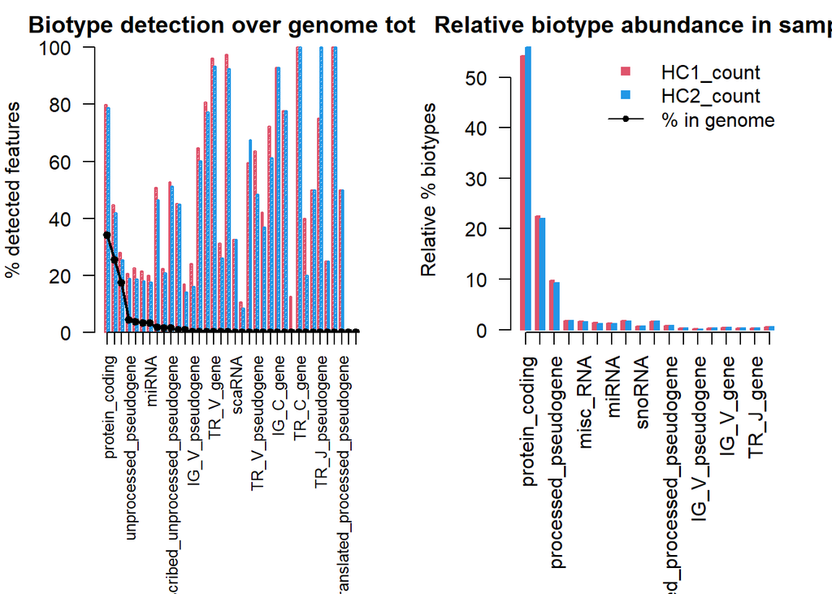

```
## [1] "Percentage of protein_coding biotype in each sample:"
## HC1_count HC2_count
##   54.2580   55.9317
## [1] "Confidence interval at 95% for the difference of percentages: HC1_count - HC2_count"
## [1] -2.2471 -1.1002
## [1] "The percentage of this biotype is significantly DIFFERENT for these two samples (p-value = 9.991e-09 )."
```

```r
par(mfrow = c(1, 2))
explo.plot(myexplodata, samples = c(1, 2), toplot = "protein_coding", plottype = "comparison")
```

**Similar to the previous plot, we observe that most of the features identified belong to protein-coding mRNA, followed by pseudogenes**

```r
mycountsbio = dat(data_NOISEQ, factor = NULL, type = "countsbio")
```

```
## [1] "Warning: 17171 features with 0 counts in all samples are to be removed for this analysis."
## [1] "Count distributions are to be computed for:"
##  [1] "HC1_count"  "HC2_count"  "HC3_count"  "HC4_count"  "HC5_count"
##  [6] "HC6_count"  "HC7_count"  "HC8_count"  "HC9_count"  "HC10_count"
## [11] "BDU1_count" "BDU2_count" "BDU3_count" "BDV1_count" "BDV2_count"
## [16] "BDV3_count" "BDV4_count" "BDV5_count" "BDV6_count"
```

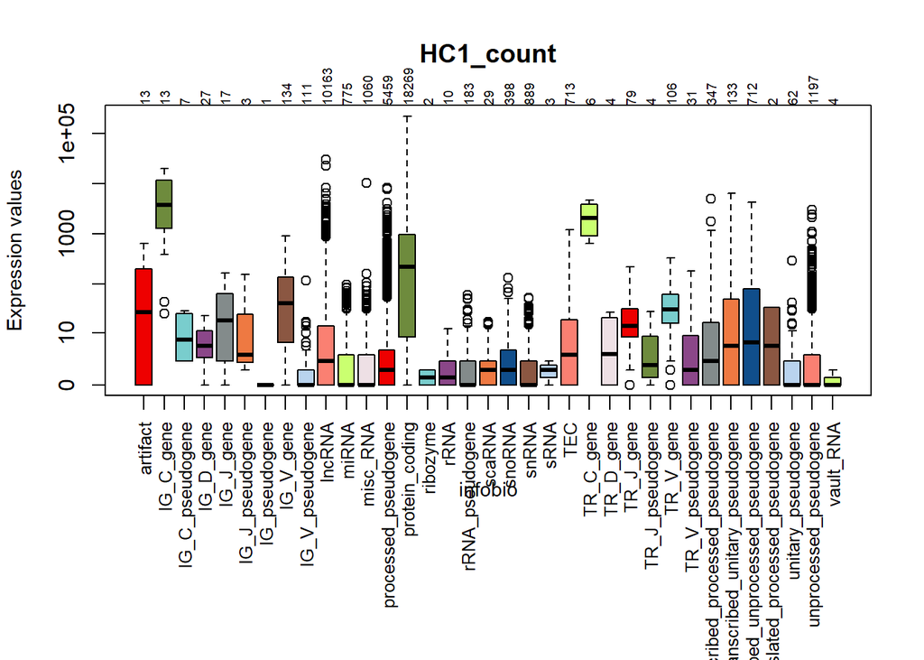

```r
explo.plot(mycountsbio, toplot = 1, samples = 1, plottype = "boxplot")
```

**This plot shows the distribution of read counts, the highest values are related to genes and pseudogenes in this sample**

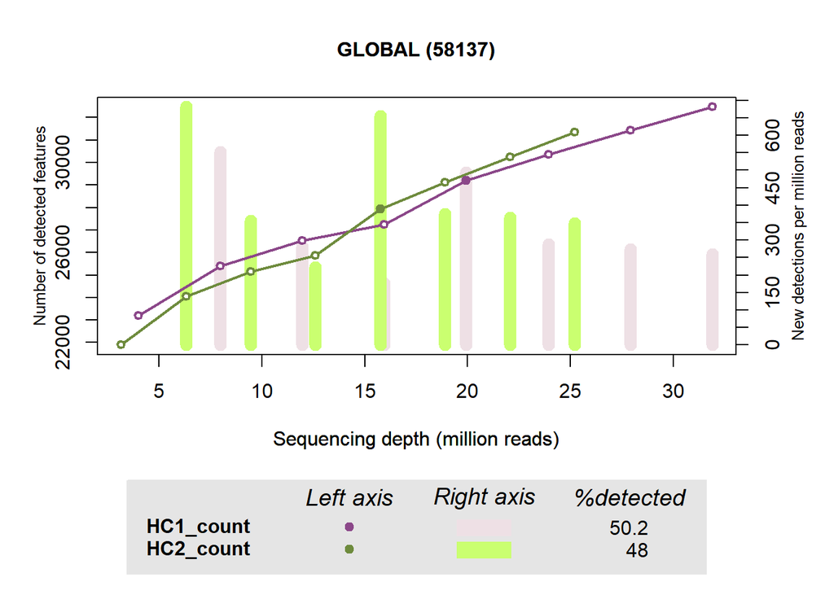

```r
mysaturation = dat(data_NOISEQ, k = 0, ndepth = 7, type = "saturation")
explo.plot(mysaturation, toplot = 1, samples = 1:2, yleftlim = NULL, yrightlim = NULL)
```

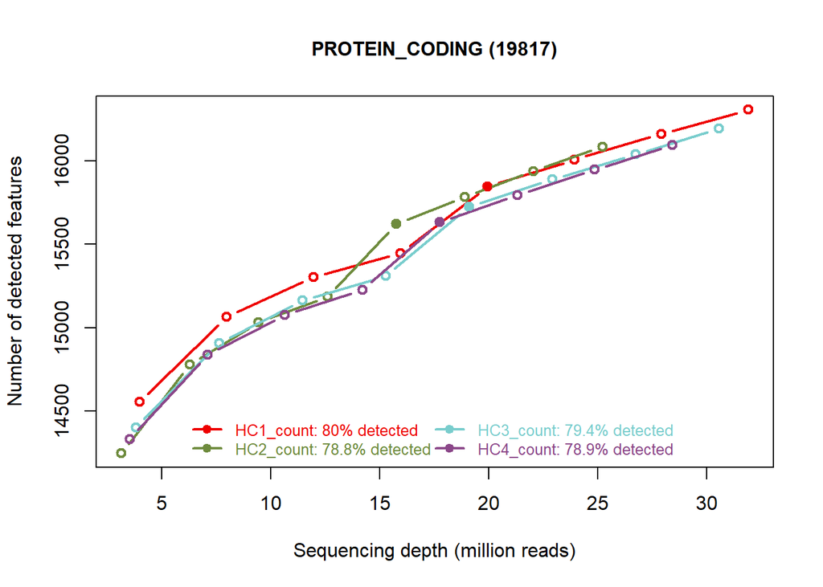

```r
explo.plot(mysaturation, toplot = "protein_coding", samples = 1:4)
```

**The plot shows the level of saturation in the sample. According to the sample, increasing the sampling depth could lead to discover more features. The second plot compares newly discovered features between 4 different samples**

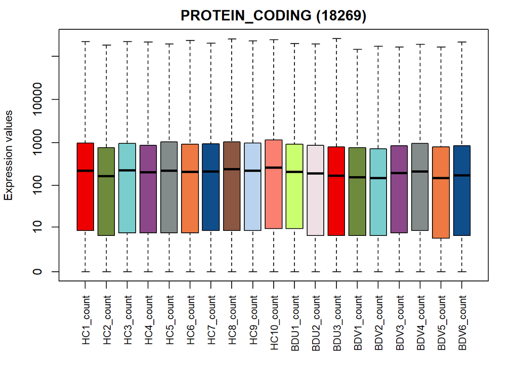

```r
explo.plot(mycountsbio, toplot = "protein_coding", samples = NULL, plottype = "boxplot")
```

**Compares the distribution of protein-coding biotyope across all the samples**

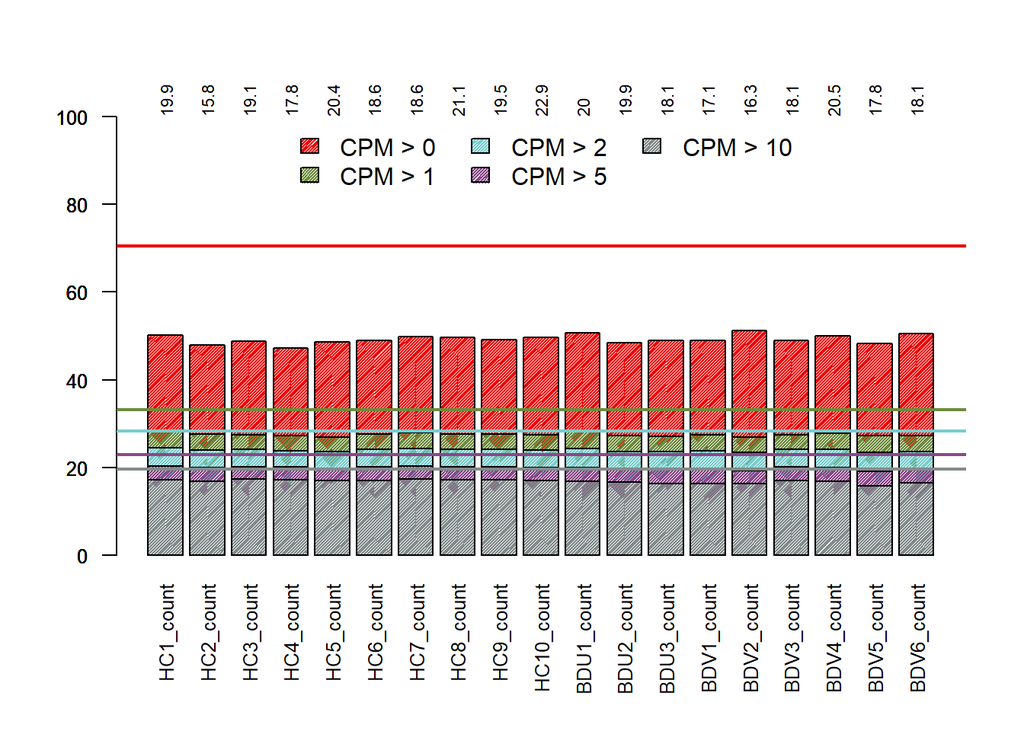

```r
explo.plot(mycountsbio, toplot = 1, samples = NULL, plottype = "barplot")
```

**This plot allow us visualize the features with low count per sample to decide a potential removal threshold. In this case, all the samples show a good amount of counts per million**

```r
mylengthbias = dat(data_NOISEQ, factor = "Group", type = "lengthbias")
```

```
## [1] "Warning: 17171 features with 0 counts in all samples are to be removed for this analysis."
## [1] "Length bias detection information is to be computed for:"
## [1] "BD patients"     "healthy control"
## [1] "BD patients"
##
## Call:
## lm(formula = datos[, i] ~ bx)
##
## Residuals:
##      Min       1Q   Median       3Q      Max
## -12.1444  -1.4850   0.0000   0.7683  17.4969
##
## Coefficients: (7 not defined because of singularities)
##             Estimate Std. Error t value Pr(>|t|)
## (Intercept)    6.272      3.802   1.650  0.10065
## bx1           -7.035      3.832  -1.836  0.06796 .
## bx2           17.654      4.053   4.356 2.18e-05 ***
## bx3           28.939      4.352   6.649 3.14e-10 ***
## bx4           23.749      4.477   5.305 3.16e-07 ***
## bx5           29.042      4.834   6.009 9.59e-09 ***
## bx6           31.204      5.319   5.866 1.99e-08 ***
## bx7           35.303      6.005   5.879 1.86e-08 ***
## bx8           21.783      7.207   3.023  0.00286 **
## bx9           20.672      9.682   2.135  0.03406 *
## bx10          25.919     16.978   1.527  0.12855
## bx11         -15.345     42.955  -0.357  0.72132
## bx12         111.437    117.567   0.948  0.34442
## bx13        -128.799    164.638  -0.782  0.43502
## bx14         -42.079     57.778  -0.728  0.46735
## bx15         296.382    168.550   1.758  0.08031 .
## bx16              NA         NA      NA       NA
## bx17              NA         NA      NA       NA
## bx18              NA         NA      NA       NA
## bx19              NA         NA      NA       NA
## bx20           2.791      5.891   0.474  0.63616
## bx21              NA         NA      NA       NA
## bx22              NA         NA      NA       NA
## bx23              NA         NA      NA       NA
## ---
## Signif. codes:  0 '***' 0.001 '**' 0.01 '*' 0.05 '.' 0.1 ' ' 1
```

[output cut: 31 more lines]

```
## bx15         278.091    164.417   1.691  0.09243 .
## bx16              NA         NA      NA       NA
## bx17              NA         NA      NA       NA
## bx18              NA         NA      NA       NA
## bx19              NA         NA      NA       NA
## bx20           2.706      5.746   0.471  0.63825
## bx21              NA         NA      NA       NA
## bx22              NA         NA      NA       NA
## bx23              NA         NA      NA       NA
## ---
## Signif. codes:  0 '***' 0.001 '**' 0.01 '*' 0.05 '.' 0.1 ' ' 1
##
## Residual standard error: 3.708 on 187 degrees of freedom
## Multiple R-squared:  0.9255, Adjusted R-squared:  0.9192
## F-statistic: 145.3 on 16 and 187 DF,  p-value: < 2.2e-16
```

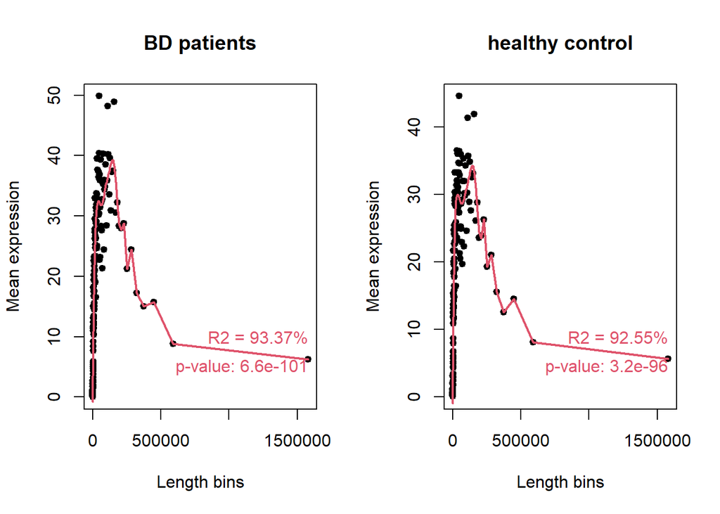

```r
explo.plot(mylengthbias, samples = NULL, toplot = "global")
```

**This plot explores if length of the features introduce bias to the analysis In this case, R2 shows a high value, indicating that the data is in fact biased by the lenght of the features**

```r
myGCbias = dat(data_NOISEQ, factor = "Group", type = "GCbias")
```

```
## [1] "Warning: 17171 features with 0 counts in all samples are to be removed for this analysis."
## [1] "GC content bias detection is to be computed for:"
## [1] "BD patients"     "healthy control"
## [1] "BD patients"
##
## Call:
## lm(formula = datos[, i] ~ bx)
##
## Residuals:
##     Min      1Q  Median      3Q     Max
## -8.3343 -2.1562 -0.3253  2.0270 16.0167
##
## Coefficients: (2 not defined because of singularities)
##              Estimate Std. Error t value Pr(>|t|)
## (Intercept)     1.934      3.482   0.555 0.579388
## bx1            -1.677      4.925  -0.340 0.733920
## bx2                NA         NA      NA       NA
## bx3         22091.756  27447.985   0.805 0.421951
## bx4          -118.418    140.055  -0.846 0.398935
## bx5             8.113     13.180   0.616 0.538971
## bx6             6.199      5.255   1.180 0.239675
## bx7            18.793      4.143   4.536 1.04e-05 ***
## bx8            10.826      3.900   2.776 0.006080 **
## bx9            13.980      3.855   3.626 0.000373 ***
## bx10           10.648      3.871   2.750 0.006553 **
## bx11            9.644      3.911   2.466 0.014583 *
## bx12           10.557      3.954   2.670 0.008279 **
## bx13           10.166      3.998   2.543 0.011831 *
## bx14           17.988      4.053   4.438 1.57e-05 ***
## bx15           11.651      4.170   2.794 0.005768 **
## bx16           16.487      4.341   3.798 0.000199 ***
## bx17           11.718      4.648   2.521 0.012560 *
## bx18           17.875      5.166   3.460 0.000673 ***
## bx19           20.992      6.219   3.376 0.000900 ***
## bx20           -1.112      9.332  -0.119 0.905315
## bx21           73.421     58.808   1.248 0.213462
## bx22         -698.118    583.949  -1.196 0.233443
## bx23               NA         NA      NA       NA
## ---
## Signif. codes:  0 '***' 0.001 '**' 0.01 '*' 0.05 '.' 0.1 ' ' 1
```

[output cut: 31 more lines]

```
## bx15           12.254      4.258   2.878  0.00449 **
## bx16           19.389      4.433   4.374 2.05e-05 ***
## bx17           14.968      4.746   3.153  0.00189 **
## bx18           21.158      5.275   4.011 8.83e-05 ***
## bx19           29.263      6.350   4.608 7.62e-06 ***
## bx20           -4.769      9.529  -0.501  0.61731
## bx21          127.913     60.051   2.130  0.03451 *
## bx22        -1189.202    596.287  -1.994  0.04761 *
## bx23               NA         NA      NA       NA
## ---
## Signif. codes:  0 '***' 0.001 '**' 0.01 '*' 0.05 '.' 0.1 ' ' 1
##
## Residual standard error: 3.556 on 182 degrees of freedom
## Multiple R-squared:  0.5897, Adjusted R-squared:  0.5423
## F-statistic: 12.46 on 21 and 182 DF,  p-value: < 2.2e-16
```

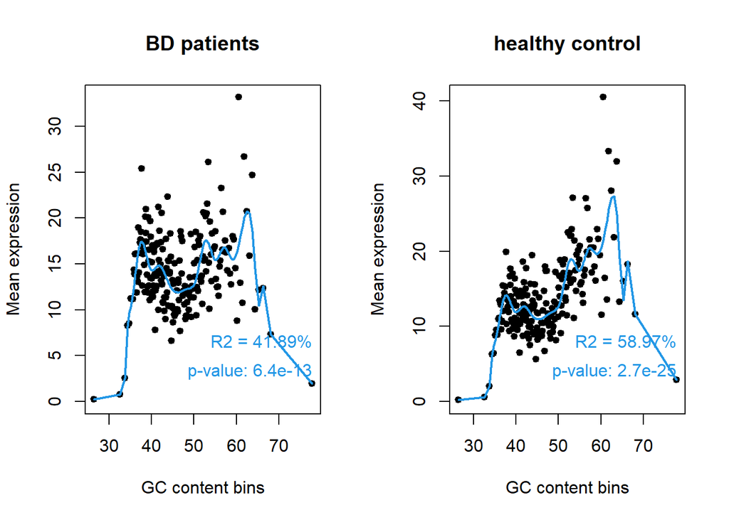

```r
explo.plot(myGCbias, samples = NULL, toplot = "global")
```

```r
#comparison of read distribution per feature of 12 samples against a reference
mycd = dat(data_NOISEQ, type = "cd", norm = FALSE, refColumn = 1)
```

```
## [1] "Warning: 17171 features with 0 counts in all samples are to be removed for this analysis."
## [1] "Reference sample is: HC1_count"
## [1] "Confidence intervals for median of M:"
##            0.14%                  99.86%                 Diagnostic Test
## HC2_count  "0.124938792202529"    "0.157687654167523"    "FAILED"
## HC3_count  "0.062614445751262"    "0.062614445751262"    "FAILED"
## HC4_count  "0.167073380721596"    "0.167073380721596"    "FAILED"
## HC5_count  "-0.0350570213759624"  "-0.0350570213759624"  "FAILED"
## HC6_count  "0.0976065563247263"   "0.0976065563247263"   "FAILED"
## HC7_count  "0.10232032635213"     "0.10232032635213"     "FAILED"
## HC8_count  "-0.0795488977419134"  "-0.0795488977419134"  "FAILED"
## HC9_count  "0.0314514213080358"   "0.0314514213080358"   "FAILED"
## HC10_count "-0.202120210366042"   "-0.202120210366042"   "FAILED"
## BDU1_count "-0.00447597069677376" "-0.00447597069677376" "FAILED"
## BDU2_count "0.00559971233022596"  "0.00559971233022596"  "FAILED"
## BDU3_count "0.138016553332103"    "0.138016553332103"    "FAILED"
## BDV1_count "0.218932389759218"    "0.218932389759218"    "FAILED"
## BDV2_count "0.143686218600787"    "0.205751027382956"    "FAILED"
## BDV3_count "0.136103426088184"    "0.136103426088184"    "FAILED"
## BDV4_count "-0.0403941618299524"  "-0.0403941618299524"  "FAILED"
## BDV5_count "0.160876307231236"    "0.160876307231236"    "FAILED"
## BDV6_count "0.140843595187623"    "0.140843595187623"    "FAILED"
## [1] "Diagnostic test: FAILED. Normalization is required to correct this bias."
```

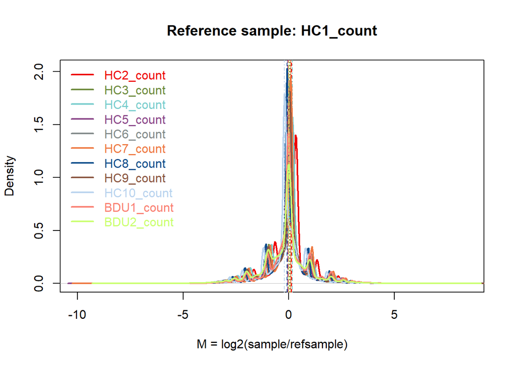

```r
explo.plot(mycd,samples = 1:12)
```

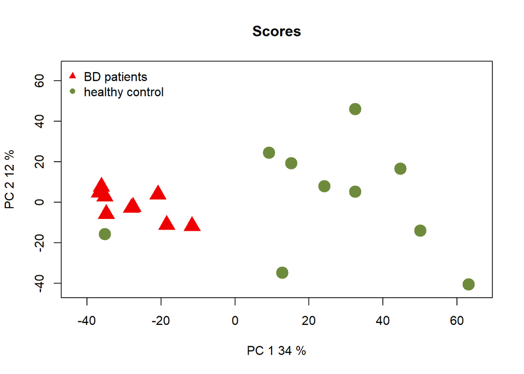

```r
#create a PCA and general QC
myPCA = dat(data_NOISEQ, type = "PCA")
explo.plot(myPCA, factor = "Group")
```

**The PCA dimension does not explain more than 50% of the variability between samples. There is one healthy sample that is grouped with the samples from ill patients. I explored this fact later on in the differential expression analysis.**

```r
QCreport(data_NOISEQ, samples = NULL, factor = "Group", norm = FALSE)
```

[output not shown]

[output cut: 150 more lines]

```
## HC6_count  "0.0976065563247263"   "0.0976065563247263"   "FAILED"
## HC7_count  "0.10232032635213"     "0.10232032635213"     "FAILED"
## HC8_count  "-0.0795488977419134"  "-0.0795488977419134"  "FAILED"
## HC9_count  "0.0314514213080358"   "0.0314514213080358"   "FAILED"
## HC10_count "-0.202120210366042"   "-0.202120210366042"   "FAILED"
## BDU1_count "-0.00447597069677376" "-0.00447597069677376" "FAILED"
## BDU2_count "0.00559971233022596"  "0.00559971233022596"  "FAILED"
## BDU3_count "0.138016553332103"    "0.138016553332103"    "FAILED"
## BDV1_count "0.218932389759218"    "0.218932389759218"    "FAILED"
## BDV2_count "0.14307910880245"     "0.208586869441239"    "FAILED"
## BDV3_count "0.136103426088184"    "0.136103426088184"    "FAILED"
## BDV4_count "-0.0403941618299524"  "-0.0403941618299524"  "FAILED"
## BDV5_count "0.160876307231236"    "0.160876307231236"    "FAILED"
## BDV6_count "0.140843595187623"    "0.140843595187623"    "FAILED"
## [1] "Diagnostic test: FAILED. Normalization is required to correct this bias."
```

```
## [1] "Percentage of protein_coding biotype in each sample:"
##     BD patients healthy control
##         47.1713         46.0739
## [1] "Confidence interval at 95% for the difference of percentages: BD patients - healthy control"
## [1] 0.5222 1.6726
## [1] "The percentage of this biotype is significantly DIFFERENT for these two samples (p-value = 0.0001806 )."
```

Normalizing the data before the DESeq2 analysis

```r
########
##normalization to correct for length of features
########

myRPKM = rpkm(assayData(data_NOISEQ)$exprs, long = lengthuse, k = 0, lc = 1)
myUQUA = uqua(assayData(data_NOISEQ)$exprs, long = lengthuse, lc = 0.5, k = 0)
myTMM = tmm(assayData(data_NOISEQ)$exprs, long = 1000, lc = 0)
```

# Analysis with DESeq2

Due to the result in the previous PCA plot I decided to check the labels of the samples. I found out that the labels given to each sample were mistakenly assigned. In the next code I reassigned all the names to the samples.

```r
pDataUSE <- pData(data_NOISEQ)
pDataUSE[1:10,1] <- "healthy_control"
pDataUSE[11:19,1] <- "BD_patients"
```

## Analysis excluding intercept

```r
GSE198533_DESeq2 <- DESeqDataSetFromMatrix(countData = GSE198533_count_filt,
                                           colData = pDataUSE,
                                           design = ~ -1 + Group)
```

**Filtering the DESeq2 data to remove low count genes.**

```r
#filtering for samples with more than 10 reads per sample in at least 6 samples
keep <- rowSums(counts(GSE198533_DESeq2) >= 10) >= 6

#Once the filter criteria is ready, we can create a modified phenodata containing genes of interest.
GSE198533_DESeq2_F <- GSE198533_DESeq2[keep,]
length(rownames(counts(GSE198533_DESeq2_F)))
```

```
## [1] 19392
```

```r
GSE198533_DESeq2 <- factor(GSE198533_DESeq2_F$Group, levels = c("healthy_control","BD_patients"))
```

**Performing the DESeq2 analysis**

```r
GSE198533_DESeq2_F<- DESeq(GSE198533_DESeq2_F)
```

```
## -- replacing outliers and refitting for 39 genes
## -- DESeq argument 'minReplicatesForReplace' = 7
## -- original counts are preserved in counts(dds)
```

```r
GSE198533_res <- results(GSE198533_DESeq2_F, contrast=c("Group","BD_patients","healthy_control"))
GSE198533_res
```

```
## log2 fold change (MLE): Group BD_patients vs healthy_control
## Wald test p-value: Group BD_patients vs healthy_control
## DataFrame with 19392 rows and 6 columns
##                  baseMean log2FoldChange     lfcSE      stat      pvalue
##                 <numeric>      <numeric> <numeric> <numeric>   <numeric>
## ENSG00000156508  195584.1      -0.121763 0.0604261  -2.01507 4.38973e-02
## ENSG00000166710  113905.2       0.257406 0.0868535   2.96368 3.03986e-03
## ENSG00000075624   78967.0      -0.185065 0.1025990  -1.80376 7.12682e-02
## ENSG00000124942   76559.2      -0.575641 0.1327335  -4.33682 1.44558e-05
## ENSG00000196924   73261.4       0.235890 0.0949678   2.48389 1.29955e-02
## ...                   ...            ...       ...       ...         ...
## ENSG00000263098   5.94026       2.266825  0.593880  3.816972 1.35099e-04
## ENSG00000258654   5.64331       0.199156  0.726517  0.274124 7.83989e-01
## ENSG00000238168   5.84831       2.978929  0.494673  6.022014 1.72260e-09
## ENSG00000236358   5.00802      -0.907674  0.687657 -1.319951 1.86851e-01
## ENSG00000196427   5.12340      -1.014723  0.744872 -1.362278 1.73110e-01
##                        padj
##                   <numeric>
## ENSG00000156508 8.84146e-02
## ENSG00000166710 9.50944e-03
## ENSG00000075624 1.31899e-01
## ENSG00000124942 9.41641e-05
## ENSG00000196924 3.23918e-02
## ...                     ...
## ENSG00000263098 6.57592e-04
## ENSG00000258654 8.45322e-01
## ENSG00000238168 3.24633e-08
## ENSG00000236358 2.85353e-01
## ENSG00000196427 2.68621e-01
```

```r
resultsNames(GSE198533_DESeq2_F)
```

```
## [1] "GroupBD_patients"     "Grouphealthy_control"
```

**Plotting the results** This is the plot that compares the mRNA expression of monocytes sampled from patients with Behcet’s disease compared to healthy controls. For each dot in the plot, Log2FoldChange higher than 0 indicates that the gene is being overexpressed in the disease model compared to the healthy control. A Log2FoldChange below 0 indicates a lower expression compared to the control. Blue dots indicate a significant difference compared to the control

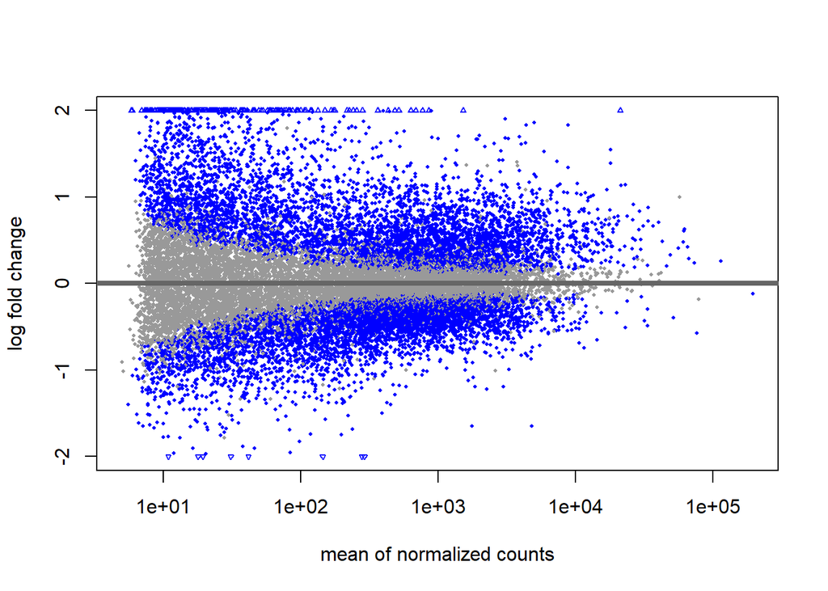

```r
plotMA(GSE198533_res, ylim=c(-2,2))
```

## Analysis including intercept

```r
pDataUSE <- pData(data_NOISEQ)
pDataUSE[1:10,1] <- "healthy_control"
pDataUSE[11:19,1] <- "BD_patients"
pDataUSE[,1] <- as.factor(pDataUSE[,1])

str(pDataUSE)
```

```
## 'data.frame':    19 obs. of  1 variable:
##  $ Group: Factor w/ 2 levels "BD_patients",..: 2 2 2 2 2 2 2 2 2 2 ...
```

```r
GSE198533_DESeq2 <- DESeqDataSetFromMatrix(countData = GSE198533_count_filt,
                                           colData = pDataUSE,
                                           design = ~ Group)
keep <- rowSums(counts(GSE198533_DESeq2) >= 10) >= 6

GSE198533_DESeq2_F <- GSE198533_DESeq2[keep,]
length(rownames(counts(GSE198533_DESeq2_F)))
```

```
## [1] 19392
```

```r
GSE198533_DESeq2_F$Group <- relevel(GSE198533_DESeq2_F$Group, ref = "healthy_control")


GSE198533_DESeq2_F<- DESeq(GSE198533_DESeq2_F)
```

```
## -- replacing outliers and refitting for 39 genes
## -- DESeq argument 'minReplicatesForReplace' = 7
## -- original counts are preserved in counts(dds)
```

```r
GSE198533_res <- results(GSE198533_DESeq2_F, contrast=c("Group","BD_patients","healthy_control"))
GSE198533_res
```

```
## log2 fold change (MLE): Group BD_patients vs healthy_control
## Wald test p-value: Group BD patients vs healthy control
## DataFrame with 19392 rows and 6 columns
##                  baseMean log2FoldChange     lfcSE      stat      pvalue
##                 <numeric>      <numeric> <numeric> <numeric>   <numeric>
## ENSG00000156508  195584.1      -0.121763 0.0604261  -2.01507 4.38973e-02
## ENSG00000166710  113905.2       0.257406 0.0868535   2.96368 3.03985e-03
## ENSG00000075624   78967.0      -0.185064 0.1025990  -1.80376 7.12683e-02
## ENSG00000124942   76559.2      -0.575641 0.1327335  -4.33682 1.44559e-05
## ENSG00000196924   73261.4       0.235890 0.0949678   2.48389 1.29954e-02
## ...                   ...            ...       ...       ...         ...
## ENSG00000263098   5.94026       2.266825  0.593880  3.816973 1.35099e-04
## ENSG00000258654   5.64331       0.199157  0.726517  0.274125 7.83988e-01
## ENSG00000238168   5.84831       2.978928  0.494673  6.022015 1.72259e-09
## ENSG00000236358   5.00802      -0.907673  0.687657 -1.319950 1.86852e-01
## ENSG00000196427   5.12340      -1.014722  0.744872 -1.362277 1.73110e-01
##                        padj
##                   <numeric>
## ENSG00000156508 8.84147e-02
## ENSG00000166710 9.50941e-03
## ENSG00000075624 1.31899e-01
## ENSG00000124942 9.41646e-05
## ENSG00000196924 3.23917e-02
## ...                     ...
## ENSG00000263098 6.57590e-04
## ENSG00000258654 8.45321e-01
## ENSG00000238168 3.24631e-08
## ENSG00000236358 2.85352e-01
## ENSG00000196427 2.68621e-01
```

```r
resultsNames(GSE198533_DESeq2_F)
```

```
## [1] "Intercept"
## [2] "Group_BD_patients_vs_healthy_control"
```

```r
lfcShrink(GSE198533_DESeq2_F,coef=c("Group_BD_patients_vs_healthy_control"))
```

```
## using 'apeglm' for LFC shrinkage. If used in published research, please cite:
##     Zhu, A., Ibrahim, J.G., Love, M.I. (2018) Heavy-tailed prior distributions for
##     sequence count data: removing the noise and preserving large differences.
##     Bioinformatics. https://doi.org/10.1093/bioinformatics/bty895
```

```
## log2 fold change (MAP): Group BD patients vs healthy control
## Wald test p-value: Group BD patients vs healthy control
## DataFrame with 19392 rows and 5 columns
##                  baseMean log2FoldChange     lfcSE      pvalue        padj
##                 <numeric>      <numeric> <numeric>   <numeric>   <numeric>
## ENSG00000156508  195584.1      -0.120659 0.0597794 4.38973e-02 8.84147e-02
## ENSG00000166710  113905.2       0.243923 0.0854478 3.03985e-03 9.50941e-03
## ENSG00000075624   78967.0      -0.171877 0.0996754 7.12683e-02 1.31899e-01
## ENSG00000124942   76559.2      -0.554038 0.1335278 1.44559e-05 9.41646e-05
## ENSG00000196924   73261.4       0.222470 0.0929986 1.29954e-02 3.23917e-02
## ...                   ...            ...       ...         ...         ...
## ENSG00000263098   5.94026      1.9271816  0.640377 1.35099e-04 6.57590e-04
## ENSG00000258654   5.64331      0.0381424  0.317929 7.83988e-01 8.45321e-01
## ENSG00000238168   5.84831      2.8137694  0.499359 1.72259e-09 3.24631e-08
## ENSG00000236358   5.00802     -0.2118941  0.383398 1.86852e-01 2.85352e-01
## ENSG00000196427   5.12340     -0.2060176  0.389182 1.73110e-01 2.68621e-01
```

```r
res_lfcShrink <- lfcShrink(GSE198533_DESeq2_F,coef=c("Group_BD_patients_vs_healthy_control"))
```

```
## using 'apeglm' for LFC shrinkage. If used in published research, please cite:
##     Zhu, A., Ibrahim, J.G., Love, M.I. (2018) Heavy-tailed prior distributions for
##     sequence count data: removing the noise and preserving large differences.
##     Bioinformatics. https://doi.org/10.1093/bioinformatics/bty895
```

**plot BD vs control including intercept**

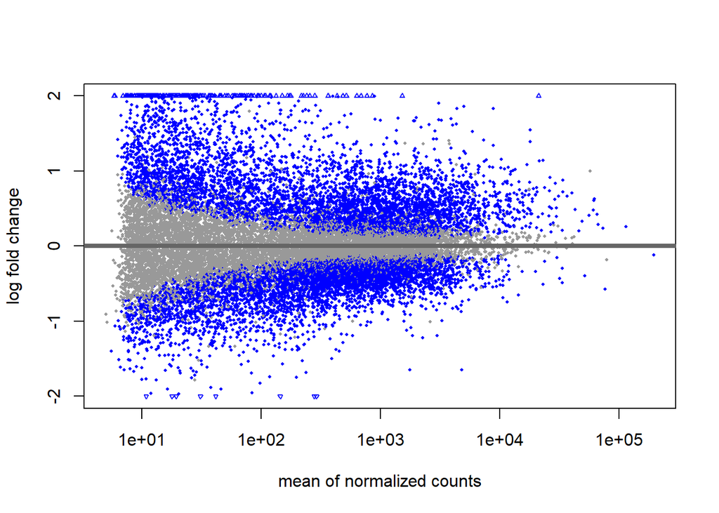

```r
plotMA(GSE198533_res, ylim=c(-2,2))
```

**plot BD vs control with shrinkage**

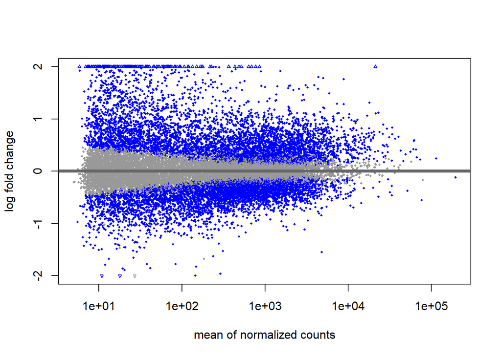

```r
plotMA(res_lfcShrink, ylim=c(-2,2))
```